# Abnormal Returns

Axel Perschmann

2016-07-24

**AbnormalReturns** implements the event study methodology and abnormal returns in particular. The event study methodology is a common way to study the effects of certain events on stock prices. It thus calculates a so-called abnormal return that measures the impact without confounding influences. As part of this method, one first has to predict a normal return in the absence of the event under study. Afterwards, one calculates the difference between the actual return and the previously predicted normal return, i.e. the abnormal return.

$AR_c(\tau) = R_c(\tau) - E(R_c(\tau)|\neg X_\tau)$, where

| Variable | Description |
| --- | --- |
| $AR_c(\tau)$ | abnormal return |
| $R_c(\tau)$ | actual return |
| $E(R_c(\tau)\|\neg X_\tau)$ | normal return, estimated during a time interval named *estimation window*. |

According to MacKinlay (1997), we calculate the normal return by the so-called *market model*. This model relies on the assumptions that asset returns are jointly multivariate normal and independently and identically distributed through time. This assumption might seem strong, but is, in practice, empirically reasonable (MacKinlay 1997). The market model assumes a stable linear relation between the market return $R_m(t)$ and the normal return, i.e. the return of the market portfolio. More precisely, the market model is for any commodity $c$

$R_c(t) = \alpha_c + \beta_cR_m(t) + \epsilon_{c,t}$, $E(\epsilon_{c,t})=0$, $Var(\epsilon_{c,t})=\sigma^2_{e_c}$

where $R_c(t)$ and $R_m(t)$ are returns in period $t$ of commodity $c$ and on the market portfolio $m$, respectively, and $\epsilon_{c,t}$ is the zero mean disturbance term. $\alpha_c$, $\beta_c$ and $\sigma^2_{e_c}$ are the parameters of the market model, determined from a regression such as *ordinary least squares (OLS)* based on the values from the estimation window.

Ultimately, the abnormal return in period $\tau$ is computed by

$AR_c(\tau) := R_c(\tau) - \alpha_c - \beta_cR_m(\tau)$.

## Implementation

Interaly the OLS regression is implemented as follows:

```r
return.commodity = commodity[indices.Estimation, ][['Close']]
return.portfolio = portfolio[indices.Estimation, ][['Close']]

M = lm(return.commodity ~ return.portfolio)
```

The final computation of the abnormal returns is implemented as follows:

```r
event.return.commodity = commodity[idx, ][['Close']]
event.return.portfolio = portfolio[idx, ][['Close']]

nd = data.frame(return.portfolio = event.return.portfolio)
abnormal = event.return.commodity - predict(M, newdata = nd)
```

## Example

This simple example reads data from two stock data sets downloaded from the Yahoo Finance platform[^1] [^2].

This package comes with three data sets precompiled and ready to use: `d.DAX`, `d.Adidas`, `d.VW`. They contain daily stock details for 253 workdays in 2015.

```r
d.DAX <- read.csv("../data-raw/DAX_2015.csv", stringsAsFactors=FALSE)
d.DAX$Date <- as.POSIXct(d.DAX$Date)
d.DAX <- d.DAX[order(d.DAX$Date),]
comment(d.DAX) <- 'DAX'
head(d.DAX)
```

```
##           Date    Open    High     Low   Close Volume Adj.Close
## 253 2015-01-02 9869.13 9879.53 9687.26 9764.73      0   9764.73
## 252 2015-01-05 9735.65 9790.27 9468.58 9473.16      0   9473.16
## 251 2015-01-06 9484.25 9624.65 9382.82 9469.66      0   9469.66
## 250 2015-01-07 9510.34 9592.37 9459.18 9518.18      0   9518.18
## 249 2015-01-08 9643.77 9855.43 9607.90 9837.61      0   9837.61
## 248 2015-01-09 9813.99 9860.18 9601.75 9648.50      0   9648.50
```

```r
d.Adidas <- read.csv("../data-raw/DAX_2015_Adidas.csv", stringsAsFactors=FALSE)
d.Adidas <- d.Adidas[d.Adidas$Volume != 0, ]
d.Adidas$Date <- as.POSIXct(d.Adidas$Date)
d.Adidas <- d.Adidas[order(d.Adidas$Date),]
comment(d.Adidas) <- 'Adidas'
head(d.Adidas)
```

```
##           Date  Open  High   Low Close  Volume Adj.Close
## 260 2015-01-02 57.72 57.86 56.25 56.42  964200   54.4843
## 259 2015-01-05 56.27 56.80 54.70 54.75 1567600   52.8716
## 258 2015-01-06 54.59 55.43 53.80 54.61 1281100   52.7364
## 257 2015-01-07 55.00 55.38 54.62 55.16 1111200   53.2675
## 256 2015-01-08 55.65 57.18 55.63 56.98 1283100   55.0251
## 255 2015-01-09 56.75 57.65 56.53 56.82 1538900   54.8705
```

In a next step `computeAbnormalReturns()` computes the abnormal returns for commodity Adidas and market portfolio DAX for the year 2015, based on an `estimationWindowLength` of 20.

The result is a data-frame with one row per abnormal return and five columns describing Date, abnormalReturn, R.squared, commodityReturn and portfolioReturn.

```r
library(AbnormalReturns)
abnormal = computeAbnormalReturn(portfolio=d.DAX, commodity=d.Adidas)
head(abnormal)
```

```
##          Date abnormalReturn R.squared commodityReturn portfolioReturn
## 21 2015-01-30      0.4713908 0.8986916           61.19        10694.32
## 22 2015-02-02      0.3299405 0.9057373           61.79        10828.01
## 23 2015-02-03      1.4813249 0.9061129           63.33        10890.95
## 24 2015-02-04      1.6381956 0.8960916           63.83        10911.32
## 25 2015-02-05      1.2093413 0.8893401           63.65        10905.41
## 26 2015-02-06      1.1372783 0.8958292           63.39        10846.39
```

```r
summary(abnormal$R.squared)
```

```
##      Min.   1st Qu.    Median      Mean   3rd Qu.      Max.
## 0.0000006 0.4211000 0.6432000 0.5959000 0.8299000 0.9614000
```

```r
summary(abnormal$abnormalReturn)
```

```
##    Min. 1st Qu.  Median    Mean 3rd Qu.    Max.
## -3.4720 -0.4255  0.6554  0.8161  1.7180  7.0700
```

## Figures

An optional parameter `showPlot` defines wether or not the commodity performance together with the computed abnormal return shall be visualized.

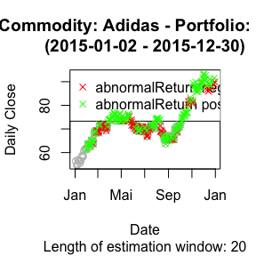

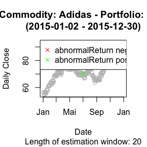

```r
computeAbnormalReturn(portfolio=d.DAX, commodity=d.Adidas, showPlot=TRUE)
computeAbnormalReturn(portfolio=d.DAX, commodity=d.Adidas, showPlot=TRUE, eventIndex=125)
```

[^1]: https://de.finance.yahoo.com/q/hp?s=%5EGDAXI accessed 24-July-2016
[^2]: https://de.finance.yahoo.com/q/hp?s=ADS.DE accessed 24-July-2016